# Risk Factor Analysis

## Outcome Variable

**Outcome Variable:** haz

## Predictor Variables

**Intervention Variable:** exclfeed36

**Adjustment Set:**

- arm
- sex
- brthmon
- W_mage
- meducyrs
- feducyrs
- hhwealth_quart
- hfoodsec
- W_mhtcm
- W_mwtkg
- W_mbmi
- vagbrth
- W_gagebrth
- W_birthwt
- W_birthlen
- W_nrooms
- W_nchldlt5
- month
- W_parity
- impfloor
- impsan
- safeh20
- delta_W_mage
- delta_meducyrs
- delta_feducyrs
- delta_hhwealth_quart
- delta_hfoodsec
- delta_W_mhtcm
- delta_W_mwtkg
- delta_W_mbmi
- delta_vagbrth
- delta_W_gagebrth
- delta_W_birthwt
- delta_W_birthlen
- delta_W_nrooms
- delta_W_nchldlt5
- delta_month
- delta_W_parity
- delta_impfloor
- delta_impsan
- delta_safeh20

## Stratifying Variables

The analysis was stratified on these variable(s):

- agecat
- studyid
- country

## Data Summary

| agecat | studyid | country | exclfeed36 | n_cell | n |
| --- | --- | --- | --- | --- | --- |
| Birth | CMC-V-BCS-2002 | INDIA | 1 | 3 | 3 |
| Birth | CMC-V-BCS-2002 | INDIA | 0 | 0 | 3 |
| Birth | EE | PAKISTAN | 1 | 3 | 7 |
| Birth | EE | PAKISTAN | 0 | 4 | 7 |
| Birth | GMS-Nepal | NEPAL | 1 | 422 | 526 |
| Birth | GMS-Nepal | NEPAL | 0 | 104 | 526 |
| Birth | IRC | INDIA | 1 | 0 | 4 |
| Birth | IRC | INDIA | 0 | 4 | 4 |
| Birth | JiVitA-3 | BANGLADESH | 1 | 8322 | 10681 |
| Birth | JiVitA-3 | BANGLADESH | 0 | 2359 | 10681 |
| Birth | JiVitA-4 | BANGLADESH | 1 | 1994 | 2517 |
| Birth | JiVitA-4 | BANGLADESH | 0 | 523 | 2517 |
| Birth | Keneba | GAMBIA | 1 | 363 | 1253 |
| Birth | Keneba | GAMBIA | 0 | 890 | 1253 |
| Birth | MAL-ED | BANGLADESH | 1 | 32 | 221 |
| Birth | MAL-ED | BANGLADESH | 0 | 189 | 221 |
| Birth | MAL-ED | BRAZIL | 1 | 5 | 65 |
| Birth | MAL-ED | BRAZIL | 0 | 60 | 65 |
| Birth | MAL-ED | INDIA | 1 | 1 | 42 |
| Birth | MAL-ED | INDIA | 0 | 41 | 42 |
| Birth | MAL-ED | NEPAL | 1 | 0 | 26 |
| Birth | MAL-ED | NEPAL | 0 | 26 | 26 |
| Birth | MAL-ED | PERU | 1 | 5 | 223 |
| Birth | MAL-ED | PERU | 0 | 218 | 223 |
| Birth | MAL-ED | SOUTH AFRICA | 1 | 1 | 105 |
| Birth | MAL-ED | SOUTH AFRICA | 0 | 104 | 105 |
| Birth | MAL-ED | TANZANIA, UNITED REPUBLIC OF | 1 | 0 | 119 |
| Birth | MAL-ED | TANZANIA, UNITED REPUBLIC OF | 0 | 119 | 119 |
| Birth | PROVIDE | BANGLADESH | 1 | 119 | 490 |
| Birth | PROVIDE | BANGLADESH | 0 | 371 | 490 |

[output cut: 66 more lines]

The following strata were considered:

- agecat: 24 months, studyid: CMC-V-BCS-2002, country: INDIA
- agecat: 24 months, studyid: EE, country: PAKISTAN
- agecat: 24 months, studyid: GMS-Nepal, country: NEPAL
- agecat: 24 months, studyid: IRC, country: INDIA
- agecat: 24 months, studyid: JiVitA-3, country: BANGLADESH
- agecat: 24 months, studyid: JiVitA-4, country: BANGLADESH
- agecat: 24 months, studyid: Keneba, country: GAMBIA
- agecat: 24 months, studyid: LCNI-5, country: MALAWI
- agecat: 24 months, studyid: MAL-ED, country: BANGLADESH
- agecat: 24 months, studyid: MAL-ED, country: BRAZIL
- agecat: 24 months, studyid: MAL-ED, country: INDIA
- agecat: 24 months, studyid: MAL-ED, country: NEPAL
- agecat: 24 months, studyid: MAL-ED, country: PERU
- agecat: 24 months, studyid: MAL-ED, country: SOUTH AFRICA
- agecat: 24 months, studyid: MAL-ED, country: TANZANIA, UNITED REPUBLIC OF
- agecat: 24 months, studyid: PROVIDE, country: BANGLADESH
- agecat: 6 months, studyid: CMC-V-BCS-2002, country: INDIA
- agecat: 6 months, studyid: EE, country: PAKISTAN
- agecat: 6 months, studyid: GMS-Nepal, country: NEPAL
- agecat: 6 months, studyid: IRC, country: INDIA
- agecat: 6 months, studyid: JiVitA-3, country: BANGLADESH
- agecat: 6 months, studyid: JiVitA-4, country: BANGLADESH
- agecat: 6 months, studyid: Keneba, country: GAMBIA
- agecat: 6 months, studyid: LCNI-5, country: MALAWI
- agecat: 6 months, studyid: MAL-ED, country: BANGLADESH
- agecat: 6 months, studyid: MAL-ED, country: BRAZIL
- agecat: 6 months, studyid: MAL-ED, country: INDIA
- agecat: 6 months, studyid: MAL-ED, country: NEPAL
- agecat: 6 months, studyid: MAL-ED, country: PERU
- agecat: 6 months, studyid: MAL-ED, country: SOUTH AFRICA
- agecat: 6 months, studyid: MAL-ED, country: TANZANIA, UNITED REPUBLIC OF
- agecat: 6 months, studyid: PROVIDE, country: BANGLADESH
- agecat: 6 months, studyid: SAS-FoodSuppl, country: INDIA
- agecat: Birth, studyid: CMC-V-BCS-2002, country: INDIA
- agecat: Birth, studyid: EE, country: PAKISTAN
- agecat: Birth, studyid: GMS-Nepal, country: NEPAL
- agecat: Birth, studyid: IRC, country: INDIA
- agecat: Birth, studyid: JiVitA-3, country: BANGLADESH
- agecat: Birth, studyid: JiVitA-4, country: BANGLADESH
- agecat: Birth, studyid: Keneba, country: GAMBIA
- agecat: Birth, studyid: MAL-ED, country: BANGLADESH
- agecat: Birth, studyid: MAL-ED, country: BRAZIL
- agecat: Birth, studyid: MAL-ED, country: INDIA
- agecat: Birth, studyid: MAL-ED, country: NEPAL
- agecat: Birth, studyid: MAL-ED, country: PERU
- agecat: Birth, studyid: MAL-ED, country: SOUTH AFRICA
- agecat: Birth, studyid: MAL-ED, country: TANZANIA, UNITED REPUBLIC OF
- agecat: Birth, studyid: PROVIDE, country: BANGLADESH

### Dropped Strata

Some strata were dropped due to rare outcomes:

- agecat: Birth, studyid: CMC-V-BCS-2002, country: INDIA
- agecat: Birth, studyid: EE, country: PAKISTAN
- agecat: Birth, studyid: IRC, country: INDIA
- agecat: Birth, studyid: MAL-ED, country: INDIA
- agecat: Birth, studyid: MAL-ED, country: NEPAL
- agecat: Birth, studyid: MAL-ED, country: SOUTH AFRICA
- agecat: Birth, studyid: MAL-ED, country: TANZANIA, UNITED REPUBLIC OF
- agecat: 6 months, studyid: CMC-V-BCS-2002, country: INDIA
- agecat: 6 months, studyid: EE, country: PAKISTAN
- agecat: 6 months, studyid: IRC, country: INDIA
- agecat: 6 months, studyid: MAL-ED, country: NEPAL
- agecat: 6 months, studyid: MAL-ED, country: SOUTH AFRICA
- agecat: 6 months, studyid: MAL-ED, country: TANZANIA, UNITED REPUBLIC OF
- agecat: 6 months, studyid: SAS-FoodSuppl, country: INDIA
- agecat: 24 months, studyid: CMC-V-BCS-2002, country: INDIA
- agecat: 24 months, studyid: EE, country: PAKISTAN
- agecat: 24 months, studyid: IRC, country: INDIA
- agecat: 24 months, studyid: MAL-ED, country: NEPAL
- agecat: 24 months, studyid: MAL-ED, country: PERU
- agecat: 24 months, studyid: MAL-ED, country: SOUTH AFRICA
- agecat: 24 months, studyid: MAL-ED, country: TANZANIA, UNITED REPUBLIC OF

## Methods Detail

We’re interested in the causal parameters $E[Y_a]$ for all values of $a \in \mathcal{A}$. These parameters represent the mean outcome if, possibly contrary to fact, we intervened to set all units to have $A=a$. Under the randomization and positivity assumptions, these are identified by the statistical parameters $\psi_a=E_W[E_{Y|A,W}(Y|A=a,W)]$. In addition, we’re interested in the mean of $Y$, $E[Y]$ under no intervention (the observed mean). We will estimate these parameters by using SuperLearner to fit the relevant likelihood factors – $E_{Y|A,W}(Y|A=a,W)$ and $p(A=a|W)$, and then updating our likelihood fit using a joint TMLE.

For unadjusted analyses ($W=\{\}$), initial likelihoods were estimated using Lrnr_glm to estimate the simple $E(Y|A)$ and Lrnr_mean to estimate $p(A)$. For adjusted analyses, a small library containing Lrnr_glmnet, Lrnr_xgboost, and Lrnr_mean was used.

Having estimated these parameters, we will then use the delta method to estimate relative risks and attributable risks relative to a prespecified baseline level of $A$.

# Results Detail

## Results Plots

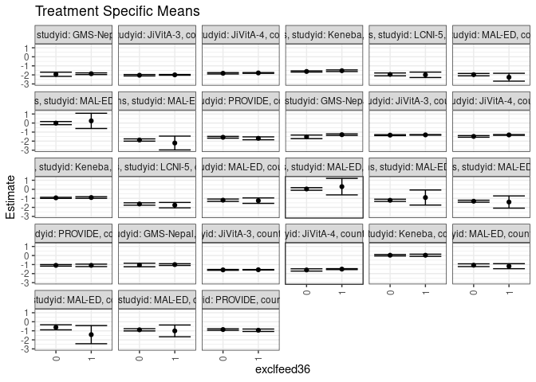

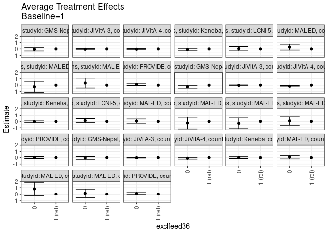

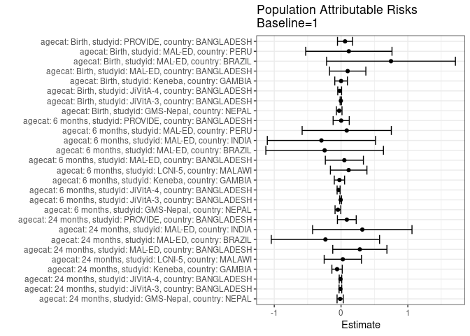

## Results Table

### Parameter: TSM

| agecat | studyid | country | intervention_level | baseline_level | estimate | ci_lower | ci_upper |
| --- | --- | --- | --- | --- | --- | --- | --- |
| Birth | GMS-Nepal | NEPAL | 1 | NA | -1.0022112 | -1.0981842 | -0.9062382 |
| Birth | GMS-Nepal | NEPAL | 0 | NA | -1.0480478 | -1.2430469 | -0.8530487 |
| Birth | JiVitA-3 | BANGLADESH | 1 | NA | -1.5731886 | -1.6012053 | -1.5451720 |
| Birth | JiVitA-3 | BANGLADESH | 0 | NA | -1.5881591 | -1.6330490 | -1.5432692 |
| Birth | JiVitA-4 | BANGLADESH | 1 | NA | -1.5029710 | -1.5561657 | -1.4497763 |
| Birth | JiVitA-4 | BANGLADESH | 0 | NA | -1.5951015 | -1.7225319 | -1.4676711 |
| Birth | Keneba | GAMBIA | 1 | NA | 0.0311301 | -0.0871772 | 0.1494375 |
| Birth | Keneba | GAMBIA | 0 | NA | 0.0341100 | -0.0467838 | 0.1150038 |
| Birth | MAL-ED | BANGLADESH | 1 | NA | -1.1795485 | -1.4561444 | -0.9029525 |
| Birth | MAL-ED | BANGLADESH | 0 | NA | -1.0701683 | -1.2216128 | -0.9187239 |
| Birth | MAL-ED | BRAZIL | 1 | NA | -1.4240000 | -2.4288338 | -0.4191662 |
| Birth | MAL-ED | BRAZIL | 0 | NA | -0.6136667 | -0.8950902 | -0.3322431 |
| Birth | MAL-ED | PERU | 1 | NA | -1.0080000 | -1.6595862 | -0.3564138 |
| Birth | MAL-ED | PERU | 0 | NA | -0.8886239 | -1.0108291 | -0.7664186 |
| Birth | PROVIDE | BANGLADESH | 1 | NA | -0.9368732 | -1.0718234 | -0.8019229 |
| Birth | PROVIDE | BANGLADESH | 0 | NA | -0.8611705 | -0.9494300 | -0.7729111 |
| 6 months | GMS-Nepal | NEPAL | 1 | NA | -1.2870603 | -1.3741734 | -1.1999471 |
| 6 months | GMS-Nepal | NEPAL | 0 | NA | -1.5260336 | -1.7237839 | -1.3282833 |
| 6 months | JiVitA-3 | BANGLADESH | 1 | NA | -1.3095136 | -1.3414881 | -1.2775391 |
| 6 months | JiVitA-3 | BANGLADESH | 0 | NA | -1.3365911 | -1.3909948 | -1.2821875 |
| 6 months | JiVitA-4 | BANGLADESH | 1 | NA | -1.3149451 | -1.3563489 | -1.2735414 |
| 6 months | JiVitA-4 | BANGLADESH | 0 | NA | -1.4786333 | -1.5696618 | -1.3876049 |
| 6 months | Keneba | GAMBIA | 1 | NA | -0.9114897 | -1.0018917 | -0.8210878 |
| 6 months | Keneba | GAMBIA | 0 | NA | -0.9448898 | -1.0047269 | -0.8850528 |
| 6 months | LCNI-5 | MALAWI | 1 | NA | -1.7537088 | -2.0532935 | -1.4541241 |
| 6 months | LCNI-5 | MALAWI | 0 | NA | -1.6270681 | -1.7582128 | -1.4959233 |
| 6 months | MAL-ED | BANGLADESH | 1 | NA | -1.2570290 | -1.5570155 | -0.9570426 |
| 6 months | MAL-ED | BANGLADESH | 0 | NA | -1.2067709 | -1.3342289 | -1.0793128 |
| 6 months | MAL-ED | BRAZIL | 1 | NA | 0.2932607 | -0.6195264 | 1.2060478 |
| 6 months | MAL-ED | BRAZIL | 0 | NA | 0.0335341 | -0.1118276 | 0.1788959 |
| 6 months | MAL-ED | INDIA | 1 | NA | -0.9116667 | -1.7458275 | -0.0775058 |
| 6 months | MAL-ED | INDIA | 0 | NA | -1.2173884 | -1.3368172 | -1.0979596 |
| 6 months | MAL-ED | PERU | 1 | NA | -1.4083333 | -2.0844008 | -0.7322659 |
| 6 months | MAL-ED | PERU | 0 | NA | -1.3211685 | -1.4309807 | -1.2113564 |
| 6 months | PROVIDE | BANGLADESH | 1 | NA | -1.0877367 | -1.2221308 | -0.9533427 |
| 6 months | PROVIDE | BANGLADESH | 0 | NA | -1.0859931 | -1.1726755 | -0.9993108 |
| 24 months | GMS-Nepal | NEPAL | 1 | NA | -1.8697241 | -1.9635134 | -1.7759348 |
| 24 months | GMS-Nepal | NEPAL | 0 | NA | -1.9303656 | -2.1630974 | -1.6976338 |
| 24 months | JiVitA-3 | BANGLADESH | 1 | NA | -1.9975826 | -2.0401087 | -1.9550565 |
| 24 months | JiVitA-3 | BANGLADESH | 0 | NA | -2.0384161 | -2.1156217 | -1.9612105 |
| 24 months | JiVitA-4 | BANGLADESH | 1 | NA | -1.7837824 | -1.8268794 | -1.7406854 |
| 24 months | JiVitA-4 | BANGLADESH | 0 | NA | -1.8230936 | -1.9006535 | -1.7455337 |
| 24 months | Keneba | GAMBIA | 1 | NA | -1.5386587 | -1.6293466 | -1.4479709 |
| 24 months | Keneba | GAMBIA | 0 | NA | -1.6221926 | -1.6895045 | -1.5548807 |
| 24 months | LCNI-5 | MALAWI | 1 | NA | -1.9918220 | -2.2914309 | -1.6922132 |
| 24 months | LCNI-5 | MALAWI | 0 | NA | -1.9481112 | -2.1070908 | -1.7891315 |
| 24 months | MAL-ED | BANGLADESH | 1 | NA | -2.2597982 | -2.6940605 | -1.8255358 |
| 24 months | MAL-ED | BANGLADESH | 0 | NA | -1.9745055 | -2.1059390 | -1.8430720 |
| 24 months | MAL-ED | BRAZIL | 1 | NA | 0.2399686 | -0.6030992 | 1.0830363 |
| 24 months | MAL-ED | BRAZIL | 0 | NA | -0.0045046 | -0.1772559 | 0.1682466 |
| 24 months | MAL-ED | INDIA | 1 | NA | -2.2088889 | -2.9737293 | -1.4440485 |
| 24 months | MAL-ED | INDIA | 0 | NA | -1.8773023 | -2.0042653 | -1.7503393 |
| 24 months | PROVIDE | BANGLADESH | 1 | NA | -1.6888637 | -1.8500154 | -1.5277119 |
| 24 months | PROVIDE | BANGLADESH | 0 | NA | -1.5746598 | -1.6709304 | -1.4783892 |

### Parameter: E(Y)

| agecat | studyid | country | intervention_level | baseline_level | estimate | ci_lower | ci_upper |
| --- | --- | --- | --- | --- | --- | --- | --- |
| Birth | GMS-Nepal | NEPAL | NA | NA | -1.0299620 | -1.1192344 | -0.9406896 |
| Birth | JiVitA-3 | BANGLADESH | NA | NA | -1.5762700 | -1.6018685 | -1.5506716 |
| Birth | JiVitA-4 | BANGLADESH | NA | NA | -1.5234724 | -1.5733491 | -1.4735957 |
| Birth | Keneba | GAMBIA | NA | NA | 0.0318156 | -0.0392907 | 0.1029220 |
| Birth | MAL-ED | BANGLADESH | NA | NA | -1.0802262 | -1.2151319 | -0.9453206 |
| Birth | MAL-ED | BRAZIL | NA | NA | -0.6760000 | -0.9521457 | -0.3998543 |
| Birth | MAL-ED | PERU | NA | NA | -0.8913004 | -1.0115814 | -0.7710195 |
| Birth | PROVIDE | BANGLADESH | NA | NA | -0.8769592 | -0.9559693 | -0.7979491 |
| 6 months | GMS-Nepal | NEPAL | NA | NA | -1.3337634 | -1.4135810 | -1.2539459 |
| 6 months | JiVitA-3 | BANGLADESH | NA | NA | -1.3152982 | -1.3444394 | -1.2861570 |
| 6 months | JiVitA-4 | BANGLADESH | NA | NA | -1.3514886 | -1.3904044 | -1.3125729 |
| 6 months | Keneba | GAMBIA | NA | NA | -0.9355822 | -0.9858754 | -0.8852889 |
| 6 months | LCNI-5 | MALAWI | NA | NA | -1.6395956 | -1.7592633 | -1.5199278 |
| 6 months | MAL-ED | BANGLADESH | NA | NA | -1.2072639 | -1.3248889 | -1.0896388 |
| 6 months | MAL-ED | BRAZIL | NA | NA | 0.0475758 | -0.0963508 | 0.1915023 |
| 6 months | MAL-ED | INDIA | NA | NA | -1.2055794 | -1.3250712 | -1.0860876 |
| 6 months | MAL-ED | PERU | NA | NA | -1.3230913 | -1.4314947 | -1.2146879 |
| 6 months | PROVIDE | BANGLADESH | NA | NA | -1.0855583 | -1.1591292 | -1.0119875 |
| 24 months | GMS-Nepal | NEPAL | NA | NA | -1.8830717 | -1.9710591 | -1.7950844 |
| 24 months | JiVitA-3 | BANGLADESH | NA | NA | -2.0071989 | -2.0453355 | -1.9690623 |
| 24 months | JiVitA-4 | BANGLADESH | NA | NA | -1.7922845 | -1.8313538 | -1.7532153 |
| 24 months | Keneba | GAMBIA | NA | NA | -1.5981956 | -1.6534947 | -1.5428965 |
| 24 months | LCNI-5 | MALAWI | NA | NA | -1.9651323 | -2.1053230 | -1.8249415 |
| 24 months | MAL-ED | BANGLADESH | NA | NA | -1.9783962 | -2.1050210 | -1.8517715 |
| 24 months | MAL-ED | BRAZIL | NA | NA | 0.0061144 | -0.1625850 | 0.1748138 |
| 24 months | MAL-ED | INDIA | NA | NA | -1.8906250 | -2.0165920 | -1.7646580 |
| 24 months | PROVIDE | BANGLADESH | NA | NA | -1.6022704 | -1.6857342 | -1.5188065 |

### Parameter: ATE

| agecat | studyid | country | intervention_level | baseline_level | estimate | ci_lower | ci_upper |
| --- | --- | --- | --- | --- | --- | --- | --- |
| Birth | GMS-Nepal | NEPAL | 1 | 1 | 0.0000000 | 0.0000000 | 0.0000000 |
| Birth | GMS-Nepal | NEPAL | 0 | 1 | -0.0458367 | -0.2562232 | 0.1645498 |
| Birth | JiVitA-3 | BANGLADESH | 1 | 1 | 0.0000000 | 0.0000000 | 0.0000000 |
| Birth | JiVitA-3 | BANGLADESH | 0 | 1 | -0.0149705 | -0.0632445 | 0.0333035 |
| Birth | JiVitA-4 | BANGLADESH | 1 | 1 | 0.0000000 | 0.0000000 | 0.0000000 |
| Birth | JiVitA-4 | BANGLADESH | 0 | 1 | -0.0921305 | -0.2296328 | 0.0453718 |
| Birth | Keneba | GAMBIA | 1 | 1 | 0.0000000 | 0.0000000 | 0.0000000 |
| Birth | Keneba | GAMBIA | 0 | 1 | 0.0029799 | -0.1294394 | 0.1353991 |
| Birth | MAL-ED | BANGLADESH | 1 | 1 | 0.0000000 | 0.0000000 | 0.0000000 |
| Birth | MAL-ED | BANGLADESH | 0 | 1 | 0.1093801 | -0.2072263 | 0.4259865 |
| Birth | MAL-ED | BRAZIL | 1 | 1 | 0.0000000 | 0.0000000 | 0.0000000 |
| Birth | MAL-ED | BRAZIL | 0 | 1 | 0.8103333 | -0.2331657 | 1.8538323 |
| Birth | MAL-ED | PERU | 1 | 1 | 0.0000000 | 0.0000000 | 0.0000000 |
| Birth | MAL-ED | PERU | 0 | 1 | 0.1193761 | -0.5435709 | 0.7823232 |
| Birth | PROVIDE | BANGLADESH | 1 | 1 | 0.0000000 | 0.0000000 | 0.0000000 |
| Birth | PROVIDE | BANGLADESH | 0 | 1 | 0.0757026 | -0.0731148 | 0.2245200 |
| 6 months | GMS-Nepal | NEPAL | 1 | 1 | 0.0000000 | 0.0000000 | 0.0000000 |
| 6 months | GMS-Nepal | NEPAL | 0 | 1 | -0.2389733 | -0.4552428 | -0.0227039 |
| 6 months | JiVitA-3 | BANGLADESH | 1 | 1 | 0.0000000 | 0.0000000 | 0.0000000 |
| 6 months | JiVitA-3 | BANGLADESH | 0 | 1 | -0.0270775 | -0.0861486 | 0.0319936 |
| 6 months | JiVitA-4 | BANGLADESH | 1 | 1 | 0.0000000 | 0.0000000 | 0.0000000 |
| 6 months | JiVitA-4 | BANGLADESH | 0 | 1 | -0.1636882 | -0.2621317 | -0.0652447 |
| 6 months | Keneba | GAMBIA | 1 | 1 | 0.0000000 | 0.0000000 | 0.0000000 |
| 6 months | Keneba | GAMBIA | 0 | 1 | -0.0334001 | -0.1409122 | 0.0741120 |
| 6 months | LCNI-5 | MALAWI | 1 | 1 | 0.0000000 | 0.0000000 | 0.0000000 |
| 6 months | LCNI-5 | MALAWI | 0 | 1 | 0.1266407 | -0.1990874 | 0.4523689 |
| 6 months | MAL-ED | BANGLADESH | 1 | 1 | 0.0000000 | 0.0000000 | 0.0000000 |
| 6 months | MAL-ED | BANGLADESH | 0 | 1 | 0.0502582 | -0.2756551 | 0.3761715 |
| 6 months | MAL-ED | BRAZIL | 1 | 1 | 0.0000000 | 0.0000000 | 0.0000000 |
| 6 months | MAL-ED | BRAZIL | 0 | 1 | -0.2597266 | -1.1842086 | 0.6647554 |
| 6 months | MAL-ED | INDIA | 1 | 1 | 0.0000000 | 0.0000000 | 0.0000000 |
| 6 months | MAL-ED | INDIA | 0 | 1 | -0.3057217 | -1.1483886 | 0.5369452 |
| 6 months | MAL-ED | PERU | 1 | 1 | 0.0000000 | 0.0000000 | 0.0000000 |
| 6 months | MAL-ED | PERU | 0 | 1 | 0.0871648 | -0.5977629 | 0.7720924 |
| 6 months | PROVIDE | BANGLADESH | 1 | 1 | 0.0000000 | 0.0000000 | 0.0000000 |
| 6 months | PROVIDE | BANGLADESH | 0 | 1 | 0.0017436 | -0.1566446 | 0.1601317 |
| 24 months | GMS-Nepal | NEPAL | 1 | 1 | 0.0000000 | 0.0000000 | 0.0000000 |
| 24 months | GMS-Nepal | NEPAL | 0 | 1 | -0.0606415 | -0.3106706 | 0.1893876 |
| 24 months | JiVitA-3 | BANGLADESH | 1 | 1 | 0.0000000 | 0.0000000 | 0.0000000 |
| 24 months | JiVitA-3 | BANGLADESH | 0 | 1 | -0.0408335 | -0.1268739 | 0.0452070 |
| 24 months | JiVitA-4 | BANGLADESH | 1 | 1 | 0.0000000 | 0.0000000 | 0.0000000 |
| 24 months | JiVitA-4 | BANGLADESH | 0 | 1 | -0.0393112 | -0.1232755 | 0.0446532 |
| 24 months | Keneba | GAMBIA | 1 | 1 | 0.0000000 | 0.0000000 | 0.0000000 |
| 24 months | Keneba | GAMBIA | 0 | 1 | -0.0835339 | -0.1949220 | 0.0278543 |
| 24 months | LCNI-5 | MALAWI | 1 | 1 | 0.0000000 | 0.0000000 | 0.0000000 |
| 24 months | LCNI-5 | MALAWI | 0 | 1 | 0.0437109 | -0.2961004 | 0.3835221 |
| 24 months | MAL-ED | BANGLADESH | 1 | 1 | 0.0000000 | 0.0000000 | 0.0000000 |
| 24 months | MAL-ED | BANGLADESH | 0 | 1 | 0.2852927 | -0.1699606 | 0.7405459 |
| 24 months | MAL-ED | BRAZIL | 1 | 1 | 0.0000000 | 0.0000000 | 0.0000000 |
| 24 months | MAL-ED | BRAZIL | 0 | 1 | -0.2444732 | -1.1055256 | 0.6165792 |
| 24 months | MAL-ED | INDIA | 1 | 1 | 0.0000000 | 0.0000000 | 0.0000000 |
| 24 months | MAL-ED | INDIA | 0 | 1 | 0.3315866 | -0.4437201 | 1.1068933 |
| 24 months | PROVIDE | BANGLADESH | 1 | 1 | 0.0000000 | 0.0000000 | 0.0000000 |
| 24 months | PROVIDE | BANGLADESH | 0 | 1 | 0.1142039 | -0.0717945 | 0.3002023 |

### Parameter: PAR

| agecat | studyid | country | intervention_level | baseline_level | estimate | ci_lower | ci_upper |
| --- | --- | --- | --- | --- | --- | --- | --- |
| Birth | GMS-Nepal | NEPAL | 1 | NA | -0.0277508 | -0.0697632 | 0.0142615 |
| Birth | JiVitA-3 | BANGLADESH | 1 | NA | -0.0030814 | -0.0137368 | 0.0075740 |
| Birth | JiVitA-4 | BANGLADESH | 1 | NA | -0.0205014 | -0.0492929 | 0.0082901 |
| Birth | Keneba | GAMBIA | 1 | NA | 0.0006855 | -0.0938753 | 0.0952463 |
| Birth | MAL-ED | BANGLADESH | 1 | NA | 0.0993222 | -0.1728065 | 0.3714509 |
| Birth | MAL-ED | BRAZIL | 1 | NA | 0.7480000 | -0.2166815 | 1.7126815 |
| Birth | MAL-ED | PERU | 1 | NA | 0.1166996 | -0.5296780 | 0.7630771 |
| Birth | PROVIDE | BANGLADESH | 1 | NA | 0.0599140 | -0.0532011 | 0.1730291 |
| 6 months | GMS-Nepal | NEPAL | 1 | NA | -0.0467032 | -0.0895907 | -0.0038156 |
| 6 months | JiVitA-3 | BANGLADESH | 1 | NA | -0.0057845 | -0.0194025 | 0.0078335 |
| 6 months | JiVitA-4 | BANGLADESH | 1 | NA | -0.0365435 | -0.0587849 | -0.0143021 |
| 6 months | Keneba | GAMBIA | 1 | NA | -0.0240924 | -0.1012258 | 0.0530410 |
| 6 months | LCNI-5 | MALAWI | 1 | NA | 0.1141132 | -0.1592678 | 0.3874943 |
| 6 months | MAL-ED | BANGLADESH | 1 | NA | 0.0497651 | -0.2352661 | 0.3347964 |
| 6 months | MAL-ED | BRAZIL | 1 | NA | -0.2456850 | -1.1263024 | 0.6349325 |
| 6 months | MAL-ED | INDIA | 1 | NA | -0.2939127 | -1.1040658 | 0.5162403 |
| 6 months | MAL-ED | PERU | 1 | NA | 0.0852420 | -0.5825642 | 0.7530482 |
| 6 months | PROVIDE | BANGLADESH | 1 | NA | 0.0021784 | -0.1186661 | 0.1230230 |
| 24 months | GMS-Nepal | NEPAL | 1 | NA | -0.0133476 | -0.0595113 | 0.0328160 |
| 24 months | JiVitA-3 | BANGLADESH | 1 | NA | -0.0096163 | -0.0296831 | 0.0104506 |
| 24 months | JiVitA-4 | BANGLADESH | 1 | NA | -0.0085021 | -0.0273273 | 0.0103231 |
| 24 months | Keneba | GAMBIA | 1 | NA | -0.0595369 | -0.1372049 | 0.0181311 |
| 24 months | LCNI-5 | MALAWI | 1 | NA | 0.0266898 | -0.2525262 | 0.3059057 |
| 24 months | MAL-ED | BANGLADESH | 1 | NA | 0.2814019 | -0.1241830 | 0.6869868 |
| 24 months | MAL-ED | BRAZIL | 1 | NA | -0.2338542 | -1.0447759 | 0.5770676 |
| 24 months | MAL-ED | INDIA | 1 | NA | 0.3182639 | -0.4259412 | 1.0624690 |
| 24 months | PROVIDE | BANGLADESH | 1 | NA | 0.0865933 | -0.0540640 | 0.2272507 |